# Aproximación de minhashing

En esta parte discutimos qué tan buena es la aproximación de minhashing que vimos en clase. Usaremos un enfoque de simulación, con un generador de documentos aleatorio.

## 1. Generador de documentos

Primero usaremos un generador simple de documentos:

```r
library(tidyverse)
set.seed(234)
generar_docs <- function(n = 2, caracteres = c(rep(" ", 3), letters[1:10])){
  comun <- paste(sample(caracteres, 400, replace = TRUE), collapse = "")
  lapply(1:n, function(i) {
    r <- as.integer(runif(1, 50, 200))
    aleatorio <- paste(sample(caracteres, r, replace = TRUE), collapse = "")
    paste(comun, aleatorio)
  })
}
textos <- generar_docs(n=2)
textos
```

```
[[1]]
[1] "gh h fjgjaeeee cbg ideifdbg hifa gdfg dbeihafhafe fb h   dhfbdaiccgdfejbeb bec  edbhjfajbhii  djbbfdhgacbi a eg ffa   gdgceef fg  dbgjdif faiiefijbb cebje   eeef  ag gi  dbjg  cbbbba hihf hiedi ihc hiebg  ffb fcbfc j  eeaj bib gc beeggcja djaeffefg a ffbfc c adec a bfa f f  bi dbejbjc  j d acbi…

[[2]]
[1] "gh h fjgjaeeee cbg ideifdbg hifa gdfg dbeihafhafe fb h   dhfbdaiccgdfejbeb bec  edbhjfajbhii  djbbfdhgacbi a eg ffa   gdgceef fg  dbgjdif faiiefijbb cebje   eeef  ag gi  dbjg  cbbbba hihf hiedi ihc hiebg  ffb fcbfc j  eeaj bib gc beeggcja djaeffefg a ffbfc c adec a bfa f f  bi dbejbjc  j d acbi…
```

```r
shingle_chars <- function(string, lowercase = FALSE, k = 4){
  # produce shingles (con repeticiones)
  if(lowercase) {
    string <- str_to_lower(string)
  }
  shingles <- seq(1, nchar(string) - k + 1) %>%
    map_chr(function(x) substr(string, x, x + k - 1))
  shingles
}
```

Con estos parámetros, las similitudes de los documentos producidos tienden a ser altas. Puedes cambiar los parámetros del generador para probar otros casos:

```r
a <- shingle_chars(textos[[1]], k = 4)
b <- shingle_chars(textos[[2]], k = 4)
textreuse::jaccard_similarity(a, b)
```

```
[1] 0.7806841
```

## 2. Método de permutaciones

Hacemos un ejercicio de simulación, usando el método de permutaciones para estimar la similitud de jaccard.

```r
generar_minhash_perms <- function(tejas, n=100){
  tejas_indice <- as.list(1:length(tejas))
  names(tejas_indice) <- tejas
  perms <- lapply(1:n, function(i){
    sample(1:length(tejas), length(tejas))
  })
  f <- function(doc_tejas){
      sapply(perms, function(p){
        indices <- p[as.integer(tejas_indice[doc_tejas])]
        min(indices)
      })
  }
  f
}
minhash <- generar_minhash_perms(union(a,b), 200)
mean(minhash(a)==minhash(b))
```

```
[1] 0.76
```

Y ahora hacemos un ejercicio de simulación

```r
calc_sim <- function(num_minhashes = 50, generador) {
  textos <- generador(n=2)
  a <- shingle_chars(textos[[1]], k = 4) %>% unique
  b <- shingle_chars(textos[[2]], k = 4) %>% unique
  minhash <- generar_minhash_perms(union(a,b), num_minhashes)
  error <- textreuse::jaccard_similarity(a, b) - mean(minhash(a)==minhash(b))
  error
}
calc_sim(50, generador = generar_docs)
```

```
[1] 0.03889328
```

```r
df_sims <- expand.grid(rep = 1:100, num_minhashes = c(20, 100, 500,1000))
system.time(
df_sims <- df_sims %>% mutate(error = map_dbl(num_minhashes,
                                              calc_sim, generar_docs))
)
```

```
   user  system elapsed
  23.35    0.09   23.46
```

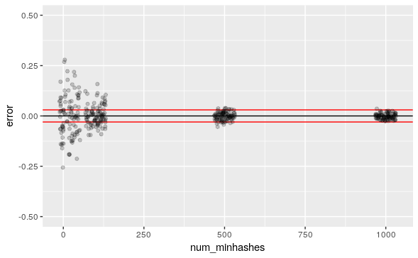

```r
ggplot(df_sims, aes(x = num_minhashes, y=error)) +
  geom_hline(yintercept = 0) +
  geom_hline(yintercept = c(-0.03,0.03), colour="red") +
  geom_jitter(alpha=0.2, height = 0) + ylim(c(-0.5,0.5))
```

## 2. Método de funciones hash

```r
calc_sim_hash <- function(num_minhashes = 50, generador) {
  textos <- generador(n=2)
  a <- shingle_chars(textos[[1]], k = 4) %>% unique
  b <- shingle_chars(textos[[2]], k = 4) %>% unique
  minhash <- textreuse::minhash_generator(num_minhashes)
  error <- textreuse::jaccard_similarity(a, b) - mean(minhash(a)==minhash(b))
  error
}
calc_sim_hash(50, generador = generar_docs)
```

```
[1] 0.001016949
```

```r
df_sims_hash <- expand.grid(rep = 1:100, num_minhashes = c(20, 100, 500, 1000))
system.time(
df_sims_hash <- df_sims_hash %>% mutate(error = map_dbl(num_minhashes,
                                              calc_sim_hash, generar_docs))
)
```

```
   user  system elapsed
  2.770   0.080   2.856
```

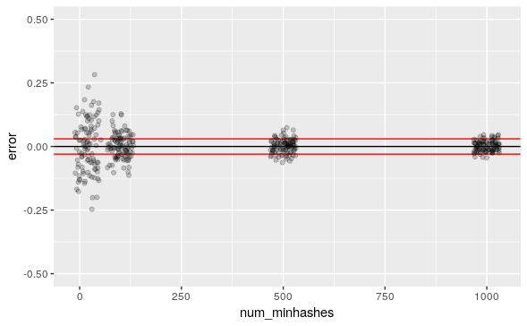

```r
ggplot(df_sims_hash, aes(x = num_minhashes, y=error)) +
  geom_hline(yintercept = 0) +
  geom_hline(yintercept = c(-0.03,0.03), colour="red") +
  geom_jitter(alpha=0.2, height = 0) + ylim(c(-0.5,0.5))
```

Puedes ver la comparación directa en esta gráfica:

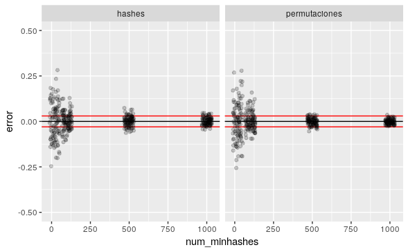

```r
df_sims$tipo ='permutaciones'
df_sims_hash$tipo ='hashes'
df <- bind_rows(df_sims, df_sims_hash)
ggplot(df, aes(x = num_minhashes, y=error)) +
  geom_hline(yintercept = 0) +
  geom_hline(yintercept = c(-0.03,0.03), colour="red") +
  geom_jitter(alpha=0.2, height = 0) + ylim(c(-0.5,0.5)) +
  facet_wrap(~tipo, nrow=1)
```

## 4. Discusión

Como vemos arriba, el error al estimar usando funciones hash es ligeramente mayor que el de métodos de permutaciones.

La razón es que para el método de permutaciones, el estimador de la similitud es insesgado (y error estándar se reduce $O(1\sqrt{n})$ cuando aumenta el número de minhashes), pero para el método de hashes, *para algunos documentos* el estimador de similitud por minhashes tiene sesgo (que se reduce también con $n$ cuando tomamos más minhashes). Esto es consecuencia de la implementación, y a fin de cuentas, del hecho de que solo estamos **simulando** permutaciones.

En el paquete **textreuse**, usamos una función *hash_string* fija que mapea cadenas a enteros. Este es el primer paso. Entonces para las tejas de un documento tenemos ahora una colección de números enteros.

Algunas de las funciones hash que escojamos posteriormente puede ser que por azar mapeen en un orden similar (o con algún otro patrón) a estos números enteros. Esto sucede rara vez on las permutaciones, pero es más común con la estrategia de textreuse (que se detalla abajo)

Para fines prácticos, compara:

- El tamaño del error posible con permutaciones y hashes
- El tiempo de cómputo para cada uno de los métodos.

### Funciones hash de textreuse

Para crear varias funciones hash diferentes, hacemos bitwise or exclusivo que mapean enteros a enteros. En **textreuse** se usan enteros grandes, aquí veremos un miniejemplo con los primero 64 enteros solamente.

El bitwise or exclusivo funciona como sigue. Supongamos que una cadena tiene hash original 53. En bits (solo vemos los primeros seis), esto es

```r
intToBits(53)[1:6]
```

```
[1] 01 00 01 00 01 01
```

Ahora escogemos un número al azar de 6 bits y lo convertimos a bits:

```r
r <- sample.int(64, 1) -1
r
```

```
[1] 60
```

```r
intToBits(r)[1:6]
```

```
[1] 00 00 01 01 01 01
```

```r
bitwXor(r, 53)
```

```
[1] 9
```

```r
intToBits(bitwXor(r, 53))[1:6]
```

```
[1] 01 00 00 01 00 00
```

```r
x <- (as.numeric(intToBits(r)[1:6]))
y <- (as.numeric(intToBits(53)[1:6]))
x
```

```
[1] 0 0 1 1 1 1
```

```r
y
```

```
[1] 1 0 1 0 1 1
```

Checa que este último resultado es igual a el o exclusivo de estos dos vectores

```r
ifelse(x!=y, 1,0)
```

```
[1] 1 0 0 1 0 0
```

```r
as.numeric(intToBits(bitwXor(r, 53))[1:6])
```

```
[1] 1 0 0 1 0 0
```